# Systemy uczące

## Analiza, przygotowanie danych i test regresji wybranych modeli

Zadanie polega na wstępnej analizie danych i przygotowaniu zbioru do regresji za pomocą kilku wybranych modeli.

Dane dotyczą wykrywania anomalii (zakłóceń) w sygnale audio; każdy wiersz opisuje inne wystąpienie anomalii, a ostatnia kolumna to szerokość zakłócenia (liczba próbek). Pozostałe kolumny to różne statystyki zebrane z otoczenia zakłócenia; pierwszy wiersz zawiera skrótowe nazwy kolumn.

| Imię | Nazwisko |
| --- | --- |
| Kornelia | Maik |

```python
import numpy as np
import matplotlib.pyplot as plt
```

### Wczytywanie danych

```python
dane = np.genfromtxt("135465-regression.txt", skip_header = 1)
```

### Wstępna eksploracja

```python
# podstawowe statystyki
att_no = len(dane[0])
means = [np.mean(dane[:, at]) for at in range(att_no)]
stds = [np.std(dane[:, at]) for at in range(att_no)]
mins = [np.min(dane[:, at]) for at in range(att_no)]
maxs = [np.max(dane[:, at]) for at in range(att_no)]

print("mean:", means[:5])
print("std:", stds[:5])
print("min:", mins[:5])
print("max:", maxs[:5])
```

```
mean: [0.01255154875846501, 0.1976463972911964, 0.24106480812641085, 0.27125764108352146, 0.3012142483069977]
std: [0.004379098548692139, 0.12170325158724242, 0.13508378989846778, 0.15596821690615278, 0.16759325978271764]
min: [0.0056871, 0.031033, 0.030934, 0.02622, 0.023948]
max: [0.034464, 0.70948, 0.8039, 0.81503, 0.86145]
```

### Wykresy pudełkowe wartości przyjmowanych przez atrybuty i klasę

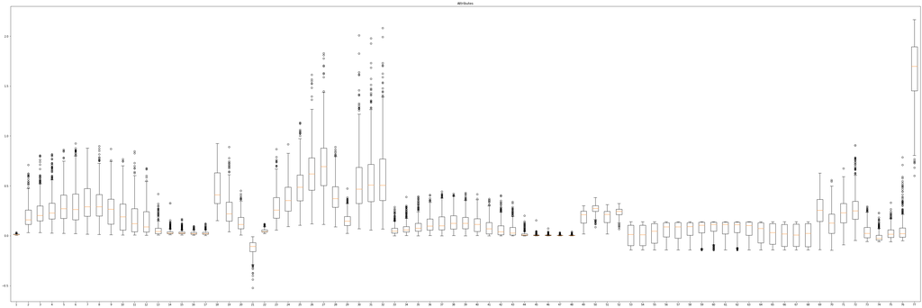

```python
fig1, ax1 = plt.subplots(figsize=(60,20))
ax1.set_title('Attributes')
_=ax1.boxplot(dane[:, :-1])
```

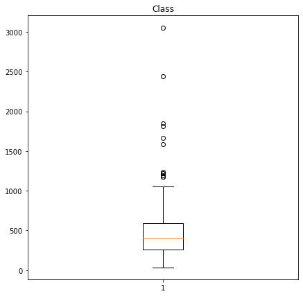

```python
fig1, ax1 = plt.subplots(figsize=(7,7))
ax1.set_title('Class')
_=ax1.boxplot(dane[:, -1])
```

## Dobór metryki

Za dwie metryki niosące użyteczną informację o jakości modelu w naszym problemie uznałam **MSE** i **explained variance** (EV). MSE wybrałam z powodu **wartości odstających** w naszych danych. Patrząc na rozkład wartości ostatniej kolumny stwierdziłam, że powinniśmy zwrócić uwagę na błędy w regresji dotyczące tych właśnie odstających wartości, dlatego odrzuciłam metryki takie jak MAE, które duże odchylenia od wartości traktują na równi z małymi odchyleniami, patrząc na ogólną zgodność modelu z danymi. Modele niewychwytujące wartości odstających są oceniane dobrze przez MAE, ale karane przez MSE. Jeśli po zeznaniu się z problemem uznalibyśmy, że powinniśmy ignorować wartości odstające i skupić się na dopasowaniu do głównego rozkładu danych, to lepszą metryką okazałby się MAE. Po wstępnej analizie danych wyszłam z założenia, że wartości odstające mogą okazać się istotne i powinniśmy brać je pod uwagę. Jako drugą metrykę wybrałam EV, ponieważ poza oceną faktycznego błędu wyrażonego w jednostce kwadratowej, przyda nam się ocena "uwzględniania wariancji" danych przez model, którą podaje nam EV. Należy pamiętać, że poza badaniem wartości EV przydaje się podejrzenie wykresu uzyskanej regresji, ponieważ model o niskim EV może świetnie sprawdzać się w regresji, w której nie potrzebujemy dużej precyzji wyników, a model, który uzyskuje dużą wartość EV może okazać się słaby w predykcji dla nowych danych.

```python
from sklearn.metrics import mean_squared_error
from sklearn.metrics import explained_variance_score

print_metrics = lambda regresor,opis,X,y: print(opis,':  Var=%.2f,'%explained_variance_score(y, regresor.predict(X)),
                                 ' MSE=%.1f'%mean_squared_error(y, regresor.predict(X)))
```

## Wybór modeli regresji

Do testów użyję:

- regresji **grzebietowej** `alpha=0.3`
- regresji **KNeighbors** `n_neighbors=9`
- **drzewa decyzyjnego** `max_depth=2` gdybyśmy nie ograniczali głębokości drzewa (i/lub minimalnej liczby elementów w liściu) doprowadzilibyśmy do przeuczenia modelu
- **Multi-Layer Perceptron** `max_iter=1000`
- **SVR** z jądrem **liniowym** `C=40.0`
- **SVR** z jądrem **RBF** `C=500, gamma=0.01`

```python
from sklearn import linear_model
from sklearn import neighbors
from sklearn.tree import DecisionTreeRegressor
from sklearn.neural_network import MLPRegressor
from sklearn.svm import SVR
```

## Normalizacja danych

Z powodu dużych różnic w zakresach wartości naszych atrybutów, zastosujemy normalizację danych.

Normalizacji/standaryzacji wymagają wszystkie metody korzystające z odległości euklidesowej pomiędzy obserwacjami. Normalizacja pozwala nam uniknąć sytuacji, w której priorytetyzujemy niektóre cechy nad innymi - przykładowo, jeśli jedna cecha ma wartości z przedziału 0-100, a druga 0-1, a odległość pomiędzy obserwacjami na pierwszej osi wynosi 1 (tylko 1% przedziału), zostaje ona traktowana jednakowo, jak odległość pomiędzy zupełnie różnymi obserwacjami na osi drugiej (0 a 1). To oznacza, że odległości na osi 1 dajemy przesadnie duże znaczenie, a to może prowadzić do błędnego porównywania obserwacji.

Wszystkie metody poza drzewem decyzyjnym korzystają z odległości euklidesowych.

Wybrałam standaryzację **RobustScaler** z powodu **wielu wartości odstających** w naszych danych.

Normalizacja wpłynęła na oceny metod następująco:

```python
from sklearn.pipeline import make_pipeline
from sklearn.preprocessing import RobustScaler

Xregr=dane[:,0:-1]
yregr=dane[:,-1]

########################### REGRESJA GRZEBIETOWA #################################
ridge = linear_model.Ridge(alpha=0.3)
ridge.fit(Xregr, yregr)
print_metrics(ridge,'Ridge',Xregr,yregr)

ridge_scaled = make_pipeline(RobustScaler(), linear_model.Ridge(alpha=0.3))
ridge_scaled.fit(Xregr, yregr)
print_metrics(ridge_scaled,'Ridge SCALED',Xregr,yregr)

########################### KNR #################################
knr = neighbors.KNeighborsRegressor(n_neighbors = 9)
knr.fit(Xregr, yregr)
print_metrics(knr,'KNeighborsRegressor',Xregr,yregr)

knr_scaled = make_pipeline(RobustScaler(), neighbors.KNeighborsRegressor(n_neighbors = 9))
knr_scaled.fit(Xregr, yregr)
print_metrics(knr_scaled,'KNeighborsRegressor SCALED',Xregr,yregr)

########################### DTR #############################################
dtr = DecisionTreeRegressor(max_depth=2)
dtr.fit(Xregr, yregr)
print_metrics(dtr,'DecisionTreeRegressor',Xregr,yregr)

# ############################# MLP ###########################################
mlp = MLPRegressor(max_iter=1000)
mlp.fit(Xregr, yregr)
print_metrics(mlp,'MLPRegressor',Xregr,yregr)

mlp_scaled = make_pipeline(RobustScaler(), MLPRegressor(max_iter=1000))
mlp_scaled.fit(Xregr, yregr)
print_metrics(mlp_scaled,'MLPRegressor SCALED',Xregr,yregr)

################################# SVR linear ######################################
svr_linear = SVR(kernel='linear', C=40.0)
svr_linear.fit(Xregr, yregr)
print_metrics(svr_linear,'SVR with linear kernel',Xregr,yregr)

svr_linear_scaled = make_pipeline(RobustScaler(), SVR(kernel='linear', C=40.0))
svr_linear_scaled.fit(Xregr, yregr)
print_metrics(svr_linear_scaled,'SVR with linear kernel SCALED',Xregr,yregr)

################################# SVR rbf ######################################
svr_rbf = SVR(kernel='rbf', C=500, gamma=0.01)
svr_rbf.fit(Xregr, yregr)
print_metrics(svr_rbf,'SVR with RBF kernel',Xregr,yregr)

svr_rbf_scaled = make_pipeline(RobustScaler(), SVR(kernel='rbf', C=500, gamma=0.01))
svr_rbf_scaled.fit(Xregr, yregr)
print_metrics(svr_rbf_scaled,'SVR with rbf kernel SCALED',Xregr,yregr)
```

```
Ridge :  Var=0.29,  MSE=63984.5
Ridge SCALED :  Var=0.35,  MSE=59164.2
KNeighborsRegressor :  Var=0.25,  MSE=67685.9
KNeighborsRegressor SCALED :  Var=0.27,  MSE=66058.8
DecisionTreeRegressor :  Var=0.32,  MSE=62029.8
```

```
MLPRegressor :  Var=0.10,  MSE=82051.7
```

```
MLPRegressor SCALED :  Var=0.47,  MSE=47781.1
SVR with linear kernel :  Var=0.13,  MSE=82080.9
SVR with linear kernel SCALED :  Var=0.23,  MSE=72279.3
SVR with RBF kernel :  Var=0.10,  MSE=85447.8
SVR with rbf kernel SCALED :  Var=0.38,  MSE=59359.2
```

```python
regressors = [ridge, ridge_scaled, knr, knr_scaled, dtr, mlp, mlp_scaled, svr_linear, svr_linear_scaled, svr_rbf, svr_rbf_scaled]

evs = [explained_variance_score(yregr, regressor.predict(Xregr)) for regressor in regressors]
mses = [mean_squared_error(yregr, regressor.predict(Xregr)) for regressor in regressors]

print("MSE:", mses)
print("Explained variance:", evs)
```

```
MSE: [63984.47226287933, 59164.20694504653, 67685.93998550845, 66058.76235264611, 62029.84168451449, 82051.65824310518, 47781.105769967224, 82080.87534393017, 72279.31798013767, 85447.79782021458, 59359.17282066106]
Explained variance: [0.29450893974897063, 0.34765705474470887, 0.2544029829122121, 0.27326555166470345, 0.31606064362900266, 0.09547243933653926, 0.4744297683742036, 0.13370555850221078, 0.22710043569091498, 0.10399962690017361, 0.38062004604796584]
```

### Wykresy metryk przed i po normalizacji

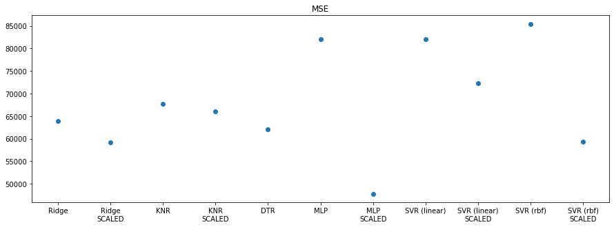

```python
regs_names = ['Ridge', 'Ridge\nSCALED', 'KNR', 'KNR\nSCALED', 'DTR', 'MLP', 'MLP\nSCALED', 'SVR (linear)', 'SVR (linear)\nSCALED', 'SVR (rbf)',  'SVR (rbf)\nSCALED']
plt.rcParams["figure.figsize"] = (15,5)
plt.scatter(regs_names, mses)
_=plt.title("MSE")
```

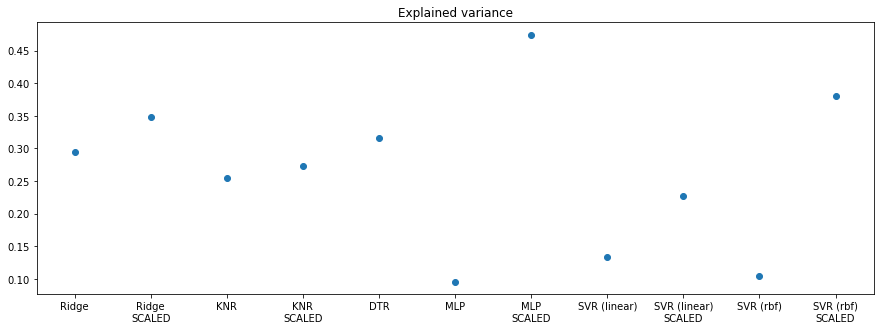

```python
plt.rcParams["figure.figsize"] = (15,5)
plt.scatter(regs_names, evs)
_=plt.title("Explained variance")
```

# Podgląd regresji

Dla kilku modeli podejrzano wykres prawdziwej wartości targetu i predykcji modelu oraz wykres targetu i predykcji dla poszczególnych próbek w danych.

### SVR rbf

Model radzi sobie świetnie na większości próbek (widzimy trend liniowy na pierwszym wykresie), ale popełnia dużo błędów przy predykcji dla wartości odstających - predykcja jest nazbyt uśredniona, niewystarczająco uwzględnia wyjątki. Jeśli naszym celem byłoby ignorowanie/delikatne uwzględnienie wartości odstających i dokładna predykcja dla większości próbek, model byłby dla nas odpowiedni.

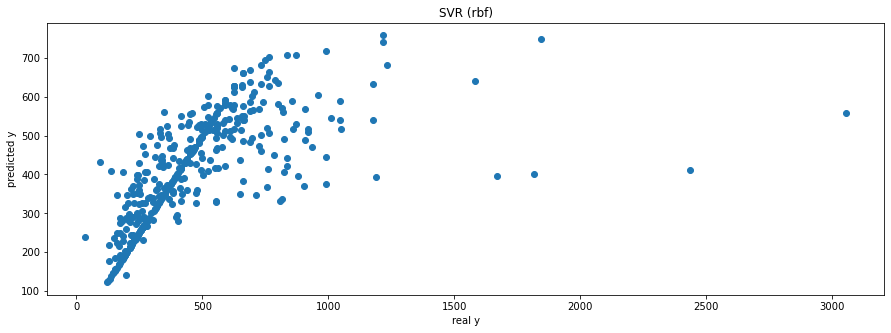

```python
plt.rcParams["figure.figsize"] = (15,5)
plt.title("SVR (rbf)")
plt.xlabel("real y")
plt.ylabel("predicted y")
predicted_y = svr_rbf_scaled.predict(Xregr)
_=plt.scatter(yregr, predicted_y)
```

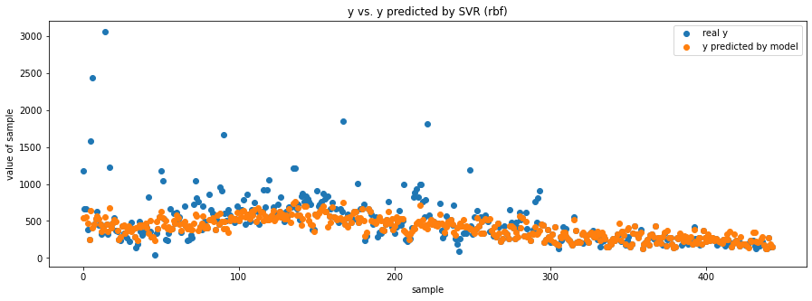

```python
y_range = [i for i in range(0, len(yregr))]
plt.xlabel("sample")
plt.ylabel("value of sample")
plt.scatter(y_range, yregr, label='real y')
plt.title("y vs. y predicted by SVR (rbf)")

predicted_y = svr_rbf_scaled.predict(Xregr)
plt.scatter(y_range, predicted_y, label='y predicted by model')
_=plt.legend()
```

### MLP

MLP lepiej radzi sobie z dostosowaniem do wartości odstających - widzimy, że jego predykcja jest bardziej rozproszona, pomimo uśredniania dla większości próbek, model stara się uwzględnić wartości odstające. Gdybyśmy mieli umieścić modele na osi mówiącej o uwzględnianiu wartości odstających, MLP byłoby pomiędzy SVR a drzewem decyzyjnym.

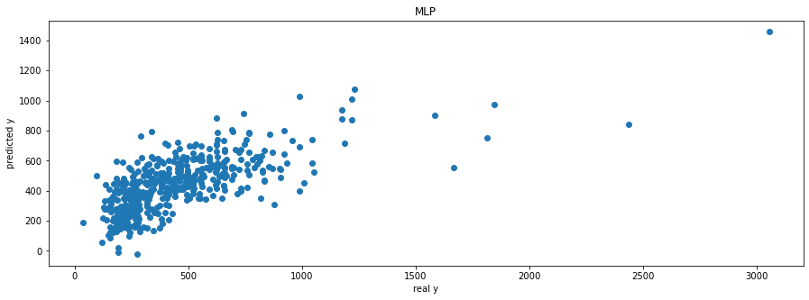

```python
plt.rcParams["figure.figsize"] = (15,5)
plt.title("MLP")
plt.xlabel("real y")
plt.ylabel("predicted y")
predicted_y = mlp_scaled.predict(Xregr)
_=plt.scatter(yregr, predicted_y)
```

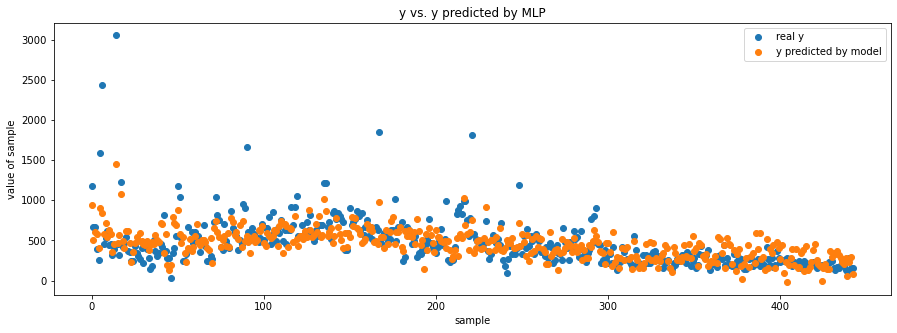

```python
y_range = [i for i in range(0, len(yregr))]
plt.xlabel("sample")
plt.ylabel("value of sample")
plt.scatter(y_range, yregr, label='real y')
plt.title("y vs. y predicted by MLP")

predicted_y = mlp_scaled.predict(Xregr)
plt.scatter(y_range, predicted_y, label='y predicted by model')
_=plt.legend()
```

### Drzewo decyzyjne

Wyjątkowym przypadkiem jest drzewo decyzyjne, które w swoim działaniu skupia się na "wyłapaniu" wartości odstających (zauważmy, że jako jedyny trafia w wartość odstającą 3056) i uśrednieniu wartości dla zbliżonych próbek. Jeśli bardzo zależałoby nam na odzwierciedleniu szerokości zakresu wartości przyjmowanych przez nasz target, ale nie na dokładności predykcji dla większości próbek, to model ten okazałby się odpowiedni.

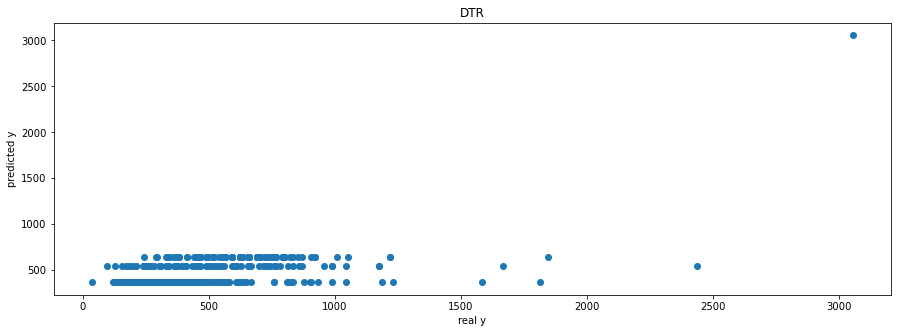

```python
plt.rcParams["figure.figsize"] = (15,5)
plt.title("DTR")
plt.xlabel("real y")
plt.ylabel("predicted y")
predicted_y = dtr.predict(Xregr)
_=plt.scatter(yregr, predicted_y)
```

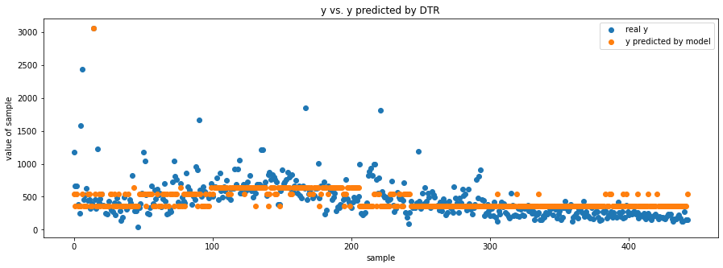

```python
y_range = [i for i in range(0, len(yregr))]
plt.xlabel("sample")
plt.ylabel("value of sample")
plt.scatter(y_range, yregr, label='real y')
plt.title("y vs. y predicted by DTR")

predicted_y = dtr.predict(Xregr)
plt.scatter(y_range, predicted_y, label='y predicted by model')
_=plt.legend()
```

## Podgląd budowy drzewa decyzyjnego

Łatwo zobaczyć jest, jak drzewo rozgałęzia się na podstawie wartości atrybutu dostarczającego najwięcej informacji, tworzy oddzielne liście dla odstających wartości (wartością liścia jest właśnie ta wartość odstająca), a dla wartości zbliżonych do siebie tworzy liście zawierające dużo elementów - wartością takiego liścia jest średnia wartość tych elementów.

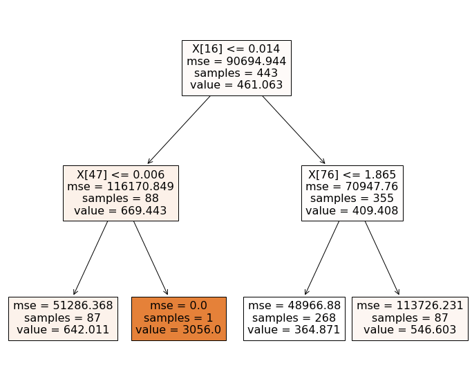

```python
from sklearn import tree
fig = plt.figure(figsize=(12,10))
_ = tree.plot_tree(dtr, filled=True)
```

# Kroswalidacja

Modele oceniono przez 10-krotną kroswalidację.

```python
from sklearn.model_selection import cross_validate

regressors = [ridge_scaled, knr_scaled, dtr, mlp_scaled, svr_linear_scaled, svr_rbf_scaled]
test_mses, test_evs = [], []

for regressor in regressors:
    scores = cross_validate(regressor, Xregr, yregr, cv=10, scoring=('explained_variance', 'neg_mean_squared_error'), return_train_score=True)
    test_evs.append(np.mean(scores['test_explained_variance']))
    test_mses.append(-np.mean(scores['test_neg_mean_squared_error']))

print("MSE:", test_mses)
print("Explained variance:", test_evs)
```

```
MSE: [96244.254212803, 100525.16918677515, 109659.68682576352, 94258.19897705838, 92713.17425830699, 90937.11604788837]
Explained variance: [-5.444493708310242, -2.3079797037333627, -1.1069267195394399, -2.9949524759864774, -2.610322007138345, -0.8227649089653735]
```

## Porównanie metryk na całym zbiorze i w kroswalidacji

Na wykresach przedstawiono porównanie metryk MSE i Explained variance na całym zbiorze i w kroswalidacji. Podczas decydowania się na model regresji należałoby podjąć decyzję o naszych priorytetach - uwzględnianie wartości odstających, czy dokładność predykcji na większości próbek? Następne należy porównać wartości metryk otrzymanych przez modele na całym zbiorze i w kroswalidacji oraz podejrzeć regresje modeli. Przydatnym zabiegiem jest znalezienie optymalnych parametrów modelu za pomocą grid search.

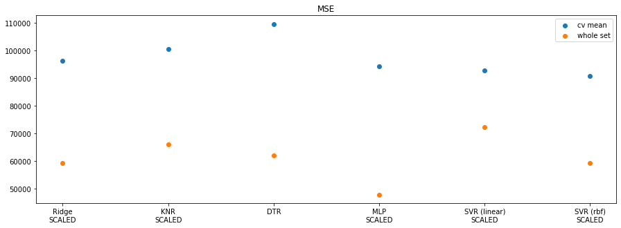

```python
indices = [1, 3, 4, 6, 8, 10]
scaled_mses = [mses[ind] for ind in indices]
regs_names = ['Ridge\nSCALED', 'KNR\nSCALED', 'DTR', 'MLP\nSCALED', 'SVR (linear)\nSCALED', 'SVR (rbf)\nSCALED']
plt.rcParams["figure.figsize"] = (15,5)

plt.scatter(regs_names, test_mses, label='cv mean')
plt.scatter(regs_names, scaled_mses, label='whole set')
plt.legend()
_=plt.title("MSE")
```

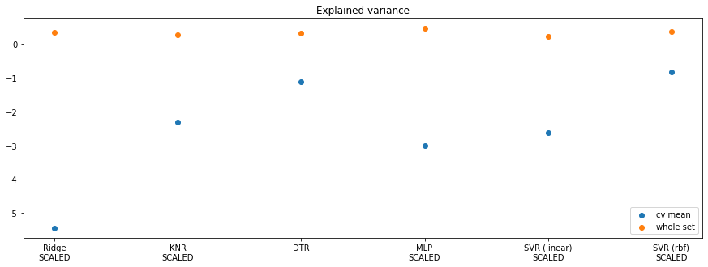

```python
indices = [1, 3, 4, 6, 8, 10]
scaled_evs = [evs[ind] for ind in indices]

regs_names = ['Ridge\nSCALED', 'KNR\nSCALED', 'DTR', 'MLP\nSCALED', 'SVR (linear)\nSCALED', 'SVR (rbf)\nSCALED']
plt.rcParams["figure.figsize"] = (15,5)
plt.scatter(regs_names, test_evs, label='cv mean')
plt.scatter(regs_names, scaled_evs, label='whole set')
plt.legend()
_=plt.title("Explained variance")
```

# Dobór parametrów modelu za pomocą GridSearch

GridSearch może pomóc nam w dobraniu optymalnych parametrów modelu. Po utworzeniu siatki wartości parametrów, dokonywana jest kroswalidacja na kombinacjach parametrów z siatki. Za optymalne uznawane są parametry, dla których model wykazał się najlepszą metryką.

Przykład pokazano na SVR z jądrem rbf, który przyjmuje dwa parametry: `C` oraz `gamma`.

```python
from sklearn.model_selection import GridSearchCV
from sklearn.pipeline import Pipeline

svr = SVR(kernel='rbf')
scaler = RobustScaler()
pipe = Pipeline(steps=[('scaler', scaler), ('svr', svr)])

param_grid = {
    'svr__C': [1, 10, 40, 100, 400],
    'svr__gamma': [0.1, 1.0, 10.0],
}

search = GridSearchCV(pipe, param_grid, scoring='neg_mean_squared_error', verbose=2, cv=3)
search.fit(Xregr, yregr)
print("Best parameter (CV score=%0.3f):" % search.best_score_)
print(search.best_params_)
```

[output not shown]

```
[Parallel(n_jobs=1)]: Using backend SequentialBackend with 1 concurrent workers.
[Parallel(n_jobs=1)]: Done   1 out of   1 | elapsed:    0.0s remaining:    0.0s
```

[output not shown]

[output cut: 22 more lines]

```
[CV] ....................... svr__C=400, svr__gamma=0.1, total=   0.0s
[CV] svr__C=400, svr__gamma=1.0 ......................................
[CV] ....................... svr__C=400, svr__gamma=1.0, total=   0.0s
[CV] svr__C=400, svr__gamma=1.0 ......................................
[CV] ....................... svr__C=400, svr__gamma=1.0, total=   0.0s
[CV] svr__C=400, svr__gamma=1.0 ......................................
[CV] ....................... svr__C=400, svr__gamma=1.0, total=   0.0s
[CV] svr__C=400, svr__gamma=10.0 .....................................
[CV] ...................... svr__C=400, svr__gamma=10.0, total=   0.0s
[CV] svr__C=400, svr__gamma=10.0 .....................................
[CV] ...................... svr__C=400, svr__gamma=10.0, total=   0.0s
[CV] svr__C=400, svr__gamma=10.0 .....................................
[CV] ...................... svr__C=400, svr__gamma=10.0, total=   0.0s
Best parameter (CV score=-117973.054):
{'svr__C': 400, 'svr__gamma': 0.1}
```

```
[Parallel(n_jobs=1)]: Done  45 out of  45 | elapsed:    1.2s finished
```